# Talent Management

April 17, 2018

## DDS Analytics… A Passion for Talent

[figure not shown]

Employee Attrition and Retention Agenda:

- Business Objectives
- Data Sourced
- Methodology
- Evaluation & Results
- Summary

## Business Objectives Include:

[figure not shown]

- Study the attrition rate for all the employees of The Agency.
- Find out the factors which contributes for the attrition from the data gathered across all Department of The Agency.
- DDS Analystics will Identify to The Agency the factors which contributed for attrition and provide suggestion to improve employee retention

## Points about the Data:

[figure not shown]

- Anonymous Data of 1,470 was extracted from The Agency HR System, cleansed, and normalized for analysis.
- Column headings were reduced to 12 character length due to R Column heading limitations.
- All Entries contain proper data types used so that when analysis is done, it can differentiate and provide relevant data.

## Methodology:

[figure not shown]

Following is a Methodolgy we used to Analyze and determine the factors which are contributing to the Attrition:

- Start : We identified what sort of data is given, what different type it is, what is the total size, some basicss about number of columns/rows, and most importantly what is the ask.
- Plan : Before started coding anything, we planned on the flow of our analysis while coding and tried to use global variables so that those can be used without having to do separate coding for each ask.
- Deploy : In this phase we made sure we follow our Plan, without having to do ad-hoc coding and clearly state the answers to the questions for our premilinary analysis.
- Analyze/Optimize : After getting premilinary analysis, we further deep dived in detailed analysis and tried to identified combination of contributing factors for Attrition.

## Descriptive Statistics for Relevant Variables

|  | Age | Monthly Income | Raise Percent | Distance | Years Working | Years at Company | Last Promoted | Years in Position |
| --- | --- | --- | --- | --- | --- | --- | --- | --- |
| Min. | 18.0 | 1009.0 | 11.0 | 1.0 | 0.0 | 0 | 0.0 | 0.0 |
| 1st Qu. | 30.0 | 2911.0 | 12.0 | 2.0 | 6.0 | 3 | 0.0 | 2.0 |
| Median | 36.0 | 4919.0 | 14.0 | 7.0 | 10.0 | 5 | 1.0 | 3.0 |
| Mean | 36.9 | 6502.9 | 15.2 | 9.2 | 11.3 | 7 | 2.2 | 4.2 |
| 3rd Qu. | 43.0 | 8379.0 | 18.0 | 14.0 | 15.0 | 9 | 3.0 | 7.0 |
| Max. | 60.0 | 19999.0 | 25.0 | 29.0 | 40.0 | 40 | 15.0 | 18.0 |

## Histograms for Age and Income

- Age is fairly normal with some slight right skew.
- Monthly Income appears heavily right skewed, and also appears bimodal at approximately 5,000 and 20,000.

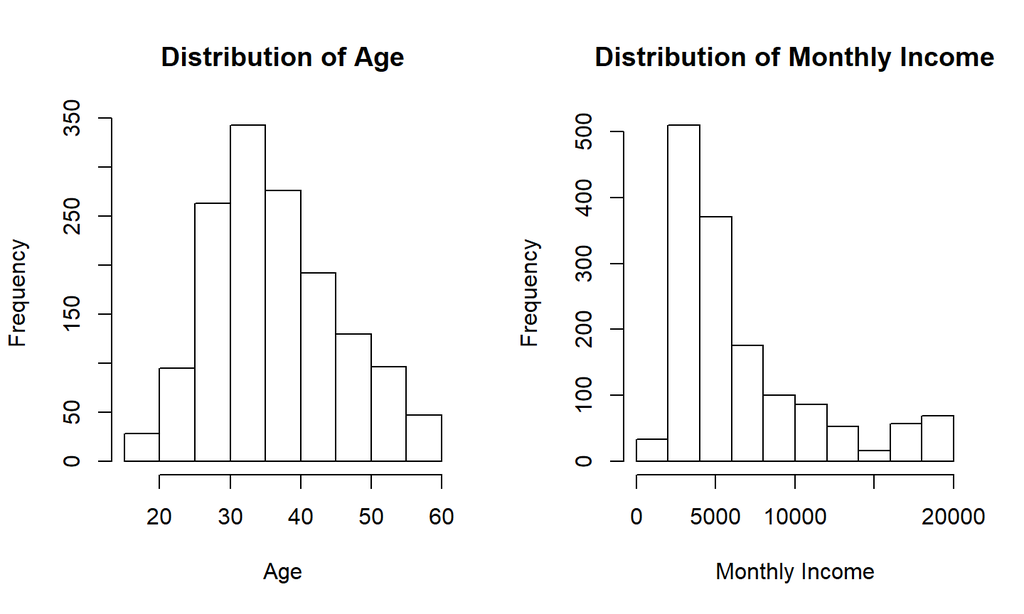

## Gender Frequency and Attrition

| Gender | Frequency | Attrition |
| --- | --- | --- |
| Female | 40% | 15% |
| Male | 60% | 17% |

## Education Frequency and Attrition

| Education | Frequency | Attrition |
| --- | --- | --- |
| Below College | 12% | 18% |
| College | 19% | 16% |
| Bachelor | 39% | 17% |
| Master | 27% | 15% |
| Doctor | 3% | 10% |

## Job Role Frequency and Attrition

| JobRole | Frequency | Attrition |
| --- | --- | --- |
| Healthcare Representative | 9% | 7% |
| Human Resources | 4% | 23% |
| Laboratory Technician | 18% | 24% |
| Manager | 7% | 5% |
| Manufacturing Director | 10% | 7% |
| Research Director | 5% | 2% |
| Research Scientist | 20% | 16% |
| Sales Executive | 22% | 17% |
| Sales Representative | 6% | 40% |

## Job Satisfaction Frequency and Attrition

| JobSatis | Frequency | Attrition |
| --- | --- | --- |
| Low | 20% | 23% |
| Medium | 19% | 16% |
| High | 30% | 17% |
| Very High | 31% | 11% |

## Job Performance Frequency and Attrition

| Performance | Frequency | Attrition |
| --- | --- | --- |
| Excellent | 85% | 16% |
| Outstanding | 15% | 16% |

## Job Level Frequency and Attrition

| JobLevel | Frequency | Attrition |
| --- | --- | --- |
| 1 | 37% | 26% |
| 2 | 36% | 10% |
| 3 | 15% | 15% |
| 4 | 7% | 5% |
| 5 | 5% | 7% |

## Stock Option Frequency and Attrition

| StockOption | Frequency | Attrition |
| --- | --- | --- |
| 0 | 43% | 24% |
| 1 | 41% | 9% |
| 2 | 11% | 8% |
| 3 | 6% | 18% |

## Job Involvement Frequency and Attrition

| JobInvolve | Frequency | Attrition |
| --- | --- | --- |
| Low | 6% | 34% |
| Medium | 26% | 19% |
| High | 59% | 14% |
| Very High | 10% | 9% |

## Training Times Last Year

| TrainLastYr | Frequency | Attrition |
| --- | --- | --- |
| 0 | 4% | 28% |
| 1 | 5% | 13% |
| 2 | 37% | 18% |
| 3 | 33% | 14% |
| 4 | 8% | 21% |
| 5 | 8% | 12% |
| 6 | 4% | 9% |

## Management Position Counts and Attrition

|  | JobRole | Count | Attrition |
| --- | --- | --- | --- |
| 4 | Manager | 102 | 5% |
| 5 | Manufacturing Director | 145 | 7% |
| 6 | Research Director | 80 | 2% |

## Monthly Income and Attrition

- Lowest quarter salary has 5x higher attrition than highest quarter salary.
- Attrition appears to be much higher in groups of lower paid employees.

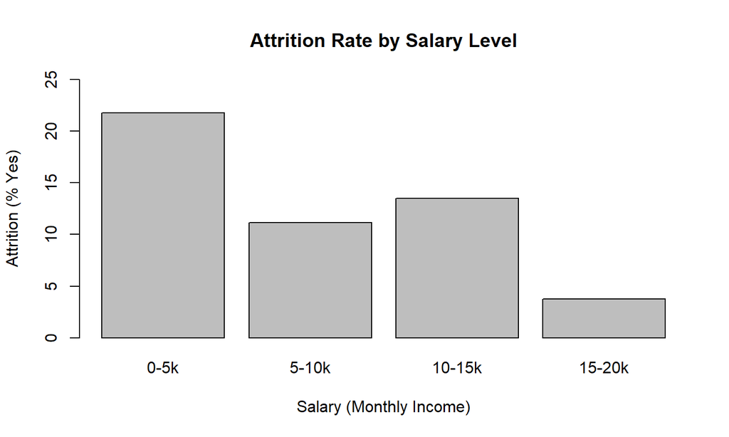

[figure not shown]

[figure not shown]

## References & Environment

- Logo adapted from: "Fondo moderno de moleculas" at Vector Gratis https://image.freepik.com/vector-gratis/fondo-moderno-de-moleculas_1035-8990.jpg
- Stick figure presentation free from: http://azart.info/presenter-medi/presenter-medi-stick-figure-holding-check-mark-presentation-clipart-great/

```
## R version 3.4.4 (2018-03-15)
```

```
## Platform: x86_64-w64-mingw32
```

```
## Packages: stats graphics grDevices utils datasets methods base
```